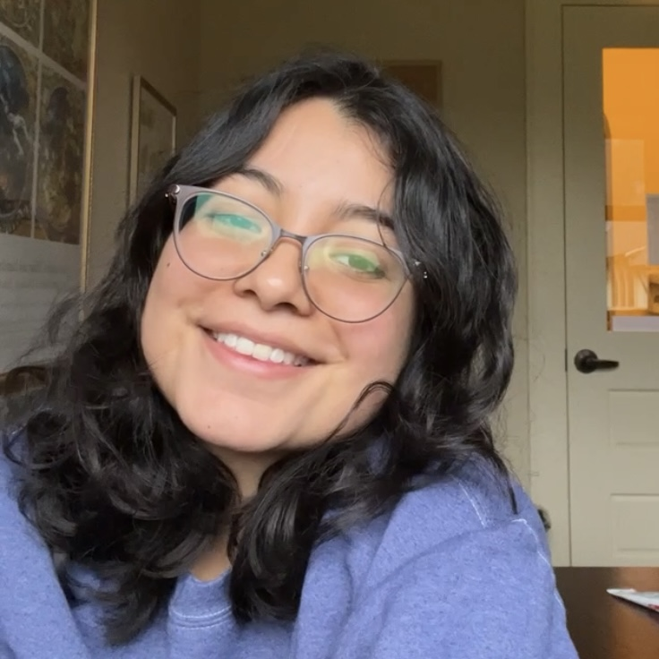

# Renee Garcia-Flores

## About myself

I am a young Mexican scientist and bioinformatician in training. Since August 2023, I’ve been pursuing my PhD at [**Cold Spring Harbor Laboratory**](https://www.cshl.edu), where my research in the [**Trotman Lab**](https://www.trotmanlab.org/) focuses on prostate tissue architecture and its role in prostate cancer. In parallel, I serve as an advocate of [**DIAS**](https://www.linkedin.com/in/dias-cshl/), a CSHL affinity group dedicated to advancing diversity, equity, and inclusion in STEM. Outside the lab, I enjoy running, reading emotionally intense fiction and historical novels, and spending time with friends and family.

## Education

**PhD Candidate in Biological Sciences** | Cold Spring Harbor Laboratory | August 2023 - Present

**B.S. in Genomic Sciences** | National Autonomous University of Mexico | August 2018 - June 2022

## Research Experience

**Lieber Institute for Brain Development** | [Leonardo Collado-Torres Lab](http://lcolladotor.github.io) | Post-baccalaureate researcher | February 2023 - August 2023

**New York Genome Center** | [Tuuli Lappalainen Lab](https://tllab.org/) | Undergraduate researcher | September 2021 - August 2022

**LANGEBIO-CINVESTAV** | [Andres Moreno-Estrada Lab](http://www.morenolab.org/) | Undergraduate researcher | August 2019 - June 2021

**Center for Genomic Sciences, UNAM** | Julio Collado-Vides Lab | Undergraduate researcher | February 2019 - December 2019

**International Laboratory for Human Genome Research, UNAM** | María Ávila-Arcos Lab | Undergraduate researcher | Summer 2019

**Center for Genomic Sciences, UNAM** | David Zamorano-Sánchez | Undergraduate researcher | January 2019 - June 2019

## Publications

**Transcriptomic analysis of the human habenula in schizophrenia**Yalcinbas EA, Ajanaku B, Nelson ED, **Garcia-Flores R**, et al. *American Journal of Psychiatry* (2025). [doi:10.1176/appi.ajp.20240776](https://doi.org/10.1176/appi.ajp.20240776).

**TrkB-dependent regulation of molecular signaling across septal cell types**. Rodriguez, L.A., Tran, M.N., **Garcia-Flores, R**. et al. *Transl Psychiatry *(2024). [doi:10.1038/s41398-024-02758-6](https://doi.org/10.1038/s41398-024-02758-6).**

**Evaluation of noninvasive biospecimens for transcriptome studies**. Martorella, M., Kasela, S., **Garcia-Flores, R**. et al. *BMC Genomics *(2023). [doi:10.1186/s12864-023-09875-4](https://doi.org/10.1186/s12864-023-09875-4).**